# IE6511 Homework 8

Done by: Aloisius Stephen and Yang Xiaozhou

```python
import numpy as np
import pandas as pd
import matplotlib
import matplotlib.pyplot as plt
from pySOT import *
from poap.controller import SerialController, ThreadController, BasicWorkerThread
%matplotlib inline
np.random.seed(6511)
np.set_printoptions(precision=3)

font = {'family' : 'sans-serif',
        'weight' : 'normal',
        'size'   : 12}

matplotlib.rc('font', **font)
```

## 1. Using PySOT with constraint handling on Keane’s Bump function (10 Points)

a) Keane's Bump with self-implementation of penalty function

```python
class KeaneConsPenalty:
    def __init__(self, dim=20):
        self.xlow = np.zeros(dim)
        self.xup = 5 * np.ones(dim)
        self.dim = dim
        self.min = -0.835
        self.integer = []
        self.continuous = np.arange(0, dim)
        self.info = str(dim)+"-dimensional Keane bump function \n" +\
                             "Global optimum: -0.835 for large n"

    # Evaluate the objective function for a single data point
    def objfunction(self, x):
        """Evaluate the Keane function  at x

        :param x: Data point
        :return: Value at x
        """
        n = len(x)
        f = -abs((sum(np.cos(x)**4)-2 * np.prod(np.cos(x)**2)) /
                    max([1E-10, np.sqrt(np.dot(1+np.arange(n), x**2))]))
        p = np.power(10,6)*(np.maximum(0,0.75 - np.prod(x))
                    + np.maximum(0,np.sum(x) - 7.5 * self.dim))
        return f + p
```

```
Number of threads: 1
Maximum number of evaluations: 300
Search strategy: CandidateDYCORS
Experimental design: Latin Hypercube
Surrogate: Cubic RBF, domain scaled to unit box
20-dimensional Keane bump function
Global optimum: -0.835 for large n
Best value: -0.5861094258534963
Best solution: [ 3.18465  0.24429  3.21494  3.05791  3.25913  3.08235  3.06121  3.13946  2.87404  2.82693  3.04239  0.45453  3.16344  0.16133  0.20677  0.23653  0.1347   0.27791  2.36673  0.71186]
```

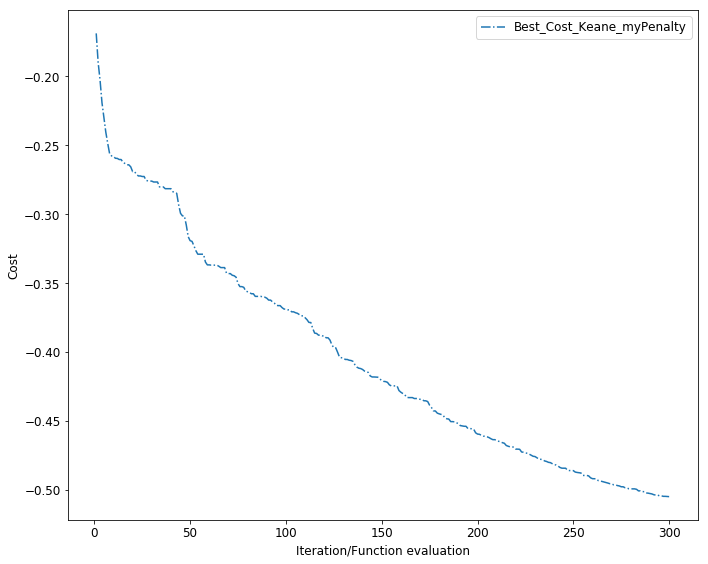

```python
nthreads = 1 # serial
maxeval = 300
penalty = 1e6
nsamples = nthreads
trial = 20

#Print setting of PySOT
print("\nNumber of threads: " + str(nthreads))
print("Maximum number of evaluations: " + str(maxeval))
print("Search strategy: CandidateDYCORS")
print("Experimental design: Latin Hypercube")
print("Surrogate: Cubic RBF, domain scaled to unit box")

# Initiate instance of the CostFunction class you created
data = KeaneConsPenalty(dim=20)
print(data.info)

# Create a strategy  and a controller
controller = ThreadController()
controller.strategy = \
    SyncStrategyNoConstraints(
        worker_id=0, data=data,
        maxeval=maxeval, nsamples=nsamples,
        response_surface=RBFInterpolant(kernel=CubicKernel, maxp=maxeval),
        exp_design=LatinHypercube(dim=data.dim, npts=2*(data.dim+1)),
        sampling_method=CandidateDYCORS(data=data, numcand=100*data.dim))

# Launch the threads with given objective function
for _ in range(nthreads):
    worker = BasicWorkerThread(controller, data.objfunction)
    controller.launch_worker(worker)

# Run the optimization strategy once
result = controller.run()
fvals = np.array([o.value for o in controller.fevals])
best, xbest = result.value, result.params[0]

Iter = np.arange(1,maxeval+1)
Trial_best_Keane_Penalty = np.column_stack((Iter,np.minimum.accumulate(fvals)))

# Run the rest of the trials
for i  in range(1,trial):
    # Create a strategy  and a controller
    controller = ThreadController()
    controller.strategy = \
        SyncStrategyNoConstraints(
            worker_id=0, data=data,
            maxeval=maxeval, nsamples=nsamples,
            response_surface=RBFInterpolant(kernel=CubicKernel, maxp=maxeval),
            exp_design=LatinHypercube(dim=data.dim, npts=2*(data.dim+1)),
            sampling_method=CandidateDYCORS(data=data, numcand=100*data.dim))

    # Launch the threads with given objective function
    for _ in range(nthreads):
        worker = BasicWorkerThread(controller, data.objfunction)
        controller.launch_worker(worker)

    result = controller.run()
    fvals = np.array([o.value for o in controller.fevals])
    Trial_best_Keane_Penalty = np.concatenate((Trial_best_Keane_Penalty,
                                        np.column_stack((Iter,np.minimum.accumulate(fvals)))),
                                        axis=0)
    if result.value < best:
        best, xbest = result.value, result.params[0]

print('Best value: {0}'.format(best))
print('Best solution: {0}'.format(
        np.array_str(xbest, max_line_width=np.inf,
        precision=5, suppress_small=True)))

Trial_best_Keane_Penalty_df = pd.DataFrame(Trial_best_Keane_Penalty,
                                           columns = ['Iteration','Cost'])

# Average of Best_Cost plot
plt.figure(figsize=[10,8])
plt.plot(Trial_best_Keane_Penalty_df.groupby('Iteration').mean().Cost, '-.')
plt.xlabel('Iteration/Function evaluation')
plt.ylabel('Cost')
plt.legend(['Best_Cost_Keane_myPenalty'])
plt.tight_layout()
```

b) Keane's Bump with pySOT Constraint handling

```python
class KeaneCons:
    def __init__(self, dim=10):
        self.xlow = np.zeros(dim)
        self.xup = 5 * np.ones(dim)
        self.dim = dim
        self.min = -0.835
        self.integer = []
        self.continuous = np.arange(0, dim)
        self.info = str(dim)+"-dimensional Keane bump function \n" +\
                             "Global optimum: -0.835 for large n"

    # Return a list with the constraint function at the given point
    def eval_ineq_constraints(self, x):
        vec = np.zeros((x.shape[0], 2))
        vec[:, 0] = 0.75 - np.prod(x) # Constraint 1
        vec[:, 1] = np.sum(x) - 7.5 * self.dim # Constraint 2
        return vec


    # Evaluate the objective function for a single data point
    def objfunction(self, x):
        """Evaluate the Keane function  at x

        :param x: Data point
        :return: Value at x
        """
        n = len(x)
        return -abs((sum(np.cos(x)**4)-2 * np.prod(np.cos(x)**2)) /
                    max([1E-10, np.sqrt(np.dot(1+np.arange(n), x**2))]))
```

```
Number of threads: 1
Maximum number of evaluations: 300
Search strategy: CandidateDYCORS
Experimental design: Latin Hypercube
Surrogate: Cubic RBF, domain scaled to unit box
20-dimensional Keane bump function
Global optimum: -0.835 for large n
Best value: -0.6910048129288353
Best solution: [ 2.89438  3.32269  3.27629  2.44037  2.99871  3.13195  0.50129  3.0965   2.09156  0.53117  0.34508  2.91683  0.6159   0.30798  0.65657  0.33054  0.32951  0.30524  0.44513  0.35894]
```

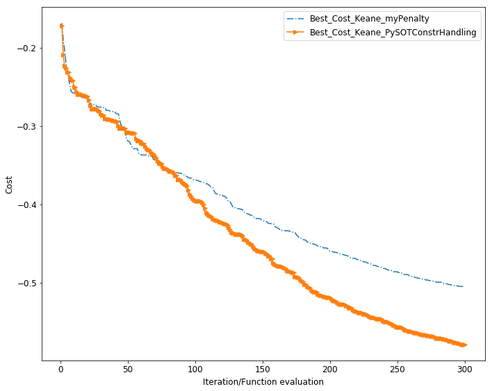

```python
nthreads = 1 # serial
maxeval = 300
penalty = 1e6
nsamples = nthreads
trial = 20

#Print setting of PySOT
print("\nNumber of threads: " + str(nthreads))
print("Maximum number of evaluations: " + str(maxeval))
print("Search strategy: CandidateDYCORS")
print("Experimental design: Latin Hypercube")
print("Surrogate: Cubic RBF, domain scaled to unit box")

# Initiate instance of the CostFunction class you created
data = KeaneCons(dim=20)
print(data.info)

# Create a strategy  and a controller
controller = ThreadController()
controller.strategy = \
    SyncStrategyPenalty(
        worker_id=0, data=data,
        maxeval=maxeval, nsamples=nsamples,
        response_surface=RBFInterpolant(kernel=CubicKernel, maxp=maxeval),
        exp_design=LatinHypercube(dim=data.dim, npts=2*(data.dim+1)),
        sampling_method=CandidateDYCORS(data=data, numcand=100*data.dim),
        penalty=penalty)

# Launch the threads with given objective function
for _ in range(nthreads):
    worker = BasicWorkerThread(controller, data.objfunction)
    controller.launch_worker(worker)

# Run the optimization strategy once
def feasible_merit(record):
    xx = np.zeros((1, record.params[0].shape[0]))
    xx[0, :] = record.params[0]
    return record.value + controller.strategy.penalty_fun(xx)[0, 0]

result = controller.run(merit=feasible_merit)
best, xbest = result.value, result.params[0]
fvals = np.array([feasible_merit(o) for o in controller.fevals])

Iter = np.arange(1,maxeval+1)
Trial_best_Keane_ConstrHandling = np.column_stack((Iter,np.minimum.accumulate(fvals)))

# Run the rest of the trials
for i  in range(1,trial):
    # Create a strategy  and a controller
    controller = ThreadController()
    controller.strategy = \
        SyncStrategyPenalty(
            worker_id=0, data=data,
            maxeval=maxeval, nsamples=nsamples,
            response_surface=RBFInterpolant(kernel=CubicKernel, maxp=maxeval),
            exp_design=LatinHypercube(dim=data.dim, npts=2*(data.dim+1)),
            sampling_method=CandidateDYCORS(data=data, numcand=100*data.dim),
            penalty=penalty)

    # Launch the threads with given objective function
    for _ in range(nthreads):
        worker = BasicWorkerThread(controller, data.objfunction)
        controller.launch_worker(worker)

    result = controller.run(merit=feasible_merit)
    fvals = np.array([feasible_merit(o) for o in controller.fevals])
    Trial_best_Keane_ConstrHandling = np.concatenate((Trial_best_Keane_ConstrHandling,
                                        np.column_stack((Iter,np.minimum.accumulate(fvals)))),
                                        axis=0)
    if result.value < best:
        best, xbest = result.value, result.params[0]


print('Best value: {0}'.format(best))
print('Best solution: {0}'.format(
        np.array_str(xbest, max_line_width=np.inf,
        precision=5, suppress_small=True)))

Trial_best_Keane_ConstrHandling_df = pd.DataFrame(Trial_best_Keane_ConstrHandling,
                                                  columns = ['Iteration','Cost'])


# Average of Best_Cost plot
plt.figure(figsize=[10,8])
plt.plot(Trial_best_Keane_Penalty_df.groupby('Iteration').mean().Cost, '-.')
plt.plot(Trial_best_Keane_ConstrHandling_df.groupby('Iteration').mean().Cost, '->')
plt.xlabel('Iteration/Function evaluation')
plt.ylabel('Cost')
plt.legend(['Best_Cost_Keane_myPenalty', 'Best_Cost_Keane_PySOTConstrHandling'])
plt.tight_layout()
```

### c. From just looking at the plot developed in 1(b), which penalty handling method works better for Keane’s Bump Function?

The PySOT Constraint Handling exhibit a better performance. This could be because the built-in penalty handling in PySOT takes into account the violation unlike the MyPenalty approach which treats the penalty as part of the objective function evaluation, therefore it performs better.

## 2. (Computer Usage) Setting up SO-MI in PySOT (15 points)

a. simpleMI objective and constraint violation function

```python
class LinearMI:
    def __init__(self):
        self.xlow = np.zeros(5)
        self.xup = np.array([10, 10, 10, 1, 1])
        self.dim = 5
        self.min = -1
        self.integer = np.arange(0, 3)
        self.continuous = np.arange(3, 5)
        self.info = str(self.dim)+"-dimensional Linear MI function \n"

    def eval_ineq_constraints(self, x):
        vec = np.zeros((x.shape[0], 3))
        vec[:, 0] = x[:, 0] + x[:, 2] - 1.6
        vec[:, 1] = 1.333 * x[:, 1] + x[:, 3] - 3
        vec[:, 2] = - x[:, 2] - x[:, 3] + x[:, 4]
        return vec

    def objfunction(self, x):
        if len(x) != self.dim:
            raise ValueError('Dimension mismatch')
        return - x[0] + 3 * x[1] + 1.5 * x[2] + 2 * x[3] - 0.5 * x[4]
```

b. Modified SO-MI Algorithm implementation

```
Number of threads: 4
Maximum number of evaluations: 100
Search strategy: CandidateDYCORS_INT,CandidateDYCORS_CONT,CandidateDYCORS,CandidateUniform
Experimental design: Symmetric Latin Hypercube
Surrogate: Cubic RBF with linear tail
5-dimensional Linear MI
Global optimum: f(1,0,0,0,0) = -1
3 integer variables
Best value: -0.9985590421883519
Best solution: [ 1.       0.       0.       0.00084  0.00047]
```

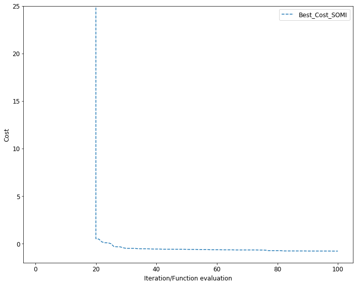

```python
from pySOT import LinearMI, MultiSampling, CandidateDYCORS, \
                  CandidateDYCORS_CONT, CandidateDYCORS_INT, \
                  CandidateUniform

nthreads = 4 # 4 points selected and evaluated simultaneously
maxeval = 100
penalty = 1e6
nsamples = nthreads
trial = 20

#Print setting of PySOT
print("\nNumber of threads: " + str(nthreads))
print("Maximum number of evaluations: " + str(maxeval))
print("Search strategy: CandidateDYCORS_INT,CandidateDYCORS_CONT,\
CandidateDYCORS,CandidateUniform")
print("Experimental design: Symmetric Latin Hypercube")
print("Surrogate: Cubic RBF with linear tail")

# Initiate instance of the CostFunction class you created
data = LinearMI()
print(data.info)

sampling_methods = [CandidateDYCORS_INT(data=data, numcand=100*data.dim), \
                    CandidateDYCORS_CONT(data=data, numcand=100*data.dim), \
                    CandidateDYCORS(data=data, numcand=100*data.dim), \
                    CandidateUniform(data=data, numcand=100*data.dim)]
cycle = [0, 1, 2, 3]
sampling_methods = MultiSampling(sampling_methods, cycle)

# Create a strategy  and a controller
controller = ThreadController()
controller.strategy = \
    SyncStrategyPenalty(
        worker_id=0, data=data,
        maxeval=maxeval, nsamples=nsamples,
        response_surface=RBFInterpolant(kernel=CubicKernel,tail=LinearTail,
                                        maxp=maxeval),
        exp_design=SymmetricLatinHypercube(dim=data.dim, npts=2*(data.dim+1)),
        sampling_method=sampling_methods,
        penalty=penalty)

# Launch the threads with given objective function
for _ in range(nthreads):
    worker = BasicWorkerThread(controller, data.objfunction)
    controller.launch_worker(worker)

# Run the optimization strategy once
def feasible_merit(record):
    xx = np.zeros((1, record.params[0].shape[0]))
    xx[0, :] = record.params[0]
    return record.value + controller.strategy.penalty_fun(xx)[0, 0]

result = controller.run(merit=feasible_merit)
fvals = np.array([feasible_merit(o) for o in controller.fevals])
best, xbest = result.value, result.params[0]

Iter = np.arange(1,maxeval+1)
Trial_best_SOMI = np.column_stack((Iter,np.minimum.accumulate(fvals)))

# Run the rest of the trials
for i  in range(1,trial):
    # Create a strategy  and a controller
    controller = ThreadController()
    controller.strategy = \
        SyncStrategyPenalty(
            worker_id=0, data=data,
            maxeval=maxeval, nsamples=nsamples,
            response_surface=RBFInterpolant(kernel=CubicKernel,tail=LinearTail,
                                            maxp=maxeval),
            exp_design=SymmetricLatinHypercube(dim=data.dim, npts=2*(data.dim+1)),
            sampling_method=sampling_methods,
            penalty=penalty)

    # Launch the threads with given objective function
    for _ in range(nthreads):
        worker = BasicWorkerThread(controller, data.objfunction)
        controller.launch_worker(worker)

    result = controller.run(merit=feasible_merit)
    fvals = np.array([feasible_merit(o) for o in controller.fevals])
    Trial_best_SOMI = np.concatenate((Trial_best_SOMI,
                                        np.column_stack((Iter,np.minimum.accumulate(fvals)))),
                                        axis=0)
    if result.value < best:
        best, xbest = result.value, result.params[0]

Trial_best_SOMI_df = pd.DataFrame(Trial_best_SOMI, columns = ['Iteration','Cost'])

print('Best value: {0}'.format(best))
print('Best solution: {0}'.format(
        np.array_str(xbest, max_line_width=np.inf,
        precision=5, suppress_small=True)))

# Average of Best_Cost plot
plt.figure(figsize=[10,8])
plt.plot(Trial_best_SOMI_df.groupby('Iteration').mean().Cost, '--')
plt.xlabel('Iteration/Function evaluation')
plt.ylabel('Cost')
plt.ylim(ymax=25, ymin = -2)
plt.legend(['Best_Cost_SOMI'])
plt.tight_layout()
```

c. Global MSRBF Implementation

```
Method: G-MSRBF
Number of threads: 4
Maximum number of evaluations: 100
Sampling method: CandidateUniform
Experimental design: Symmetric Latin Hypercube
Surrogate: Cubic RBF with linear tail
5-dimensional Linear MI
Global optimum: f(1,0,0,0,0) = -1
3 integer variables
Best value: -0.816317584139665
Best solution: [ 1.       0.       0.       0.10151  0.03866]
```

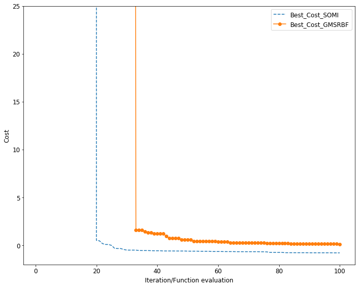

```python
nthreads = 4 # 4 points selected and evaluated simultaneously
maxeval = 100
penalty = 1e6
nsamples = nthreads
trial = 20

#Print setting of PySOT
print("\nMethod: G-MSRBF")
print("Number of threads: " + str(nthreads))
print("Maximum number of evaluations: " + str(maxeval))
print("Sampling method: CandidateUniform")
print("Experimental design: Symmetric Latin Hypercube")
print("Surrogate: Cubic RBF with linear tail")

# Initiate instance of the CostFunction class you created
data = LinearMI()
print(data.info)
# Cycling through weights when sampling
sampling_methods = [CandidateUniform(data=data, numcand=100*data.dim, weights=[0.2, 0.8]), \
                    CandidateUniform(data=data, numcand=100*data.dim, weights=[0.4, 0.6]), \
                    CandidateUniform(data=data, numcand=100*data.dim, weights=[0.6, 0.4]), \
                    CandidateUniform(data=data, numcand=100*data.dim, weights=[0.9, 0.1]), \
                    CandidateUniform(data=data, numcand=100*data.dim, weights=[0.95, 0.05]), \
                    CandidateUniform(data=data, numcand=100*data.dim, weights=[1, 0])]
cycle = [0, 1, 2, 3, 4, 5]
sampling_methods = MultiSampling(sampling_methods, cycle)

controller = ThreadController()
controller.strategy = \
    SyncStrategyPenalty(
        worker_id=0, data=data,
        maxeval=maxeval, nsamples=nsamples,
        exp_design=SymmetricLatinHypercube(dim=data.dim, npts=2*(data.dim+1)),
        response_surface=RBFInterpolant(kernel=CubicKernel, tail=LinearTail,
                                        maxp=maxeval),
        sampling_method=sampling_methods,
        penalty=penalty)

# Launch the threads and give them access to the objective function
for _ in range(nthreads):
    worker = BasicWorkerThread(controller, data.objfunction)
    controller.launch_worker(worker)

# Run the optimization strategy
result = controller.run(merit=feasible_merit)
fvals = np.array([feasible_merit(o) for o in controller.fevals])
best, xbest = result.value, result.params[0]

Iter = np.arange(1,maxeval+1)
Trial_best_GMSRBF = np.column_stack((Iter,np.minimum.accumulate(fvals)))

# Run the rest of the trials
for i  in range(1,trial):
    controller = ThreadController()
    controller.strategy = \
        SyncStrategyPenalty(
            worker_id=0, data=data,
            maxeval=maxeval, nsamples=nsamples,
            exp_design=SymmetricLatinHypercube(dim=data.dim, npts=2*(data.dim+1)),
            response_surface=RBFInterpolant(kernel=CubicKernel, tail=LinearTail,
                                            maxp=maxeval),
            sampling_method=sampling_methods,
            penalty=penalty)

    # Launch the threads and give them access to the objective function
    for _ in range(nthreads):
        worker = BasicWorkerThread(controller, data.objfunction)
        controller.launch_worker(worker)

    result = controller.run(merit=feasible_merit)
    fvals = np.array([feasible_merit(o) for o in controller.fevals])
    Trial_best_GMSRBF = np.concatenate((Trial_best_GMSRBF,
                                        np.column_stack((Iter,np.minimum.accumulate(fvals)))),
                                       axis=0)
    if result.value < best:
        best, xbest = result.value, result.params[0]

print('Best value: {0}'.format(best))
print('Best solution: {0}'.format(
        np.array_str(xbest, max_line_width=np.inf,
        precision=5, suppress_small=True)))

Trial_best_GMSRBF_df = pd.DataFrame(Trial_best_GMSRBF, columns = ['Iteration','Cost'])

# Average of Best_Cost plot
plt.figure(figsize=[10,8])
plt.plot(Trial_best_SOMI_df.groupby('Iteration').mean().Cost, '--')
plt.plot(Trial_best_GMSRBF_df.groupby('Iteration').mean().Cost, '-o')
plt.xlabel('Iteration/Function evaluation')
plt.ylabel('Cost')
plt.ylim(ymax=25, ymin = -2)
plt.legend(['Best_Cost_SOMI', 'Best_Cost_GMSRBF'])
plt.tight_layout()
```

### From looking at the plot, does it appear as if one algorithm dominates the others?

Based on the plot, it can be seen that SO-MI dominates the GMSRBF. This is most probably because in the SO-MI implementation, the sampling takes into account the integer constraints of the 3 integer variables, and is therefore able to perform better.

## 3. Short Answer Questions (no computer necessary)

Statements:  
*A. Uses non-dominated sorting to evaluate fitness of solutions.*  
True for NSGA-II only

*B. Uses the Hypervolume metric to select new points for expensive evaluation.*  
True for GOMORS only

*C. Can select more than one point for expensive evaluation in each algorithm iteration.*  
True for both GOMORS and NSGA-II

*D. Uses Kriging surrogate (Gaussian Process Model) to help pick a point for expensive evaluation.*  
Neither of the two algorithm

*E. Can be applied to problems with more than two objectives.*  
True for both GOMORS and NSGA-II

**What characteristics of your problem and the number of available evaluations would help you select among the 2 algorithms mentioned above? How many surrogate surfaces are fitted in GOMORS?**

If there are only a limited number of available evaluations, or calculation of objective function is expensive, then GOMORS should be chosen.

In GOMORS the surrogate surface fitted is equal to the number of objectives in the problem.

### 4. Explain what “restart” is for some surrogate global optimization methods.Explain when and why LMSRBF will restart and answer the same question for DYCORS. Is there a difference between the two methods. Explain the advantages and disadvantages of restarting.

"Restart" refers to re-initializing using a different experiment design, such as in the LMSRBF. While for DYCORS, only in the DYCORS-LMSRBF is there a "Restart", which refers to the adjustment of the step size.

##### LMSRBF

For LMSRBF, it will restart when it appears to have converged to a local optimum. The restart happens if the number of step size reduction exceeds $r_{max}$. Step size is reduced by half every time consecutive 'failed' iteration exceeds the pre-determined tolerance parameter.

This restart is carried out so that the search will be able to get out of a local optimum and a global optimization can be achieved.

The advantage is that starting with a clean slate allows for the algorithm to search in a new trajectory, and helps it to find a new local optimum point.

The disadvantage is the significant number of evaluations needed to get a new experimental design, such as 2(d+1) points in the Symmetric Latin Hypercube Design, for each restart.

##### DYCORS

For DYCORS-LMSRBF, the 'restart' happens when the number of consecutive 'successful' or 'failed' iterations exceeds the pre-determined tolerance parameter. In the case of exceeding the number of 'failed' tolerance, the step size is reduced by half to help speed up the convergence. While in the case of exceeding the 'successful' tolerance, the step size is doubled, so that a larger solution space can be explored through the next perturbation. On the hand, for DYCORS-DDS, the step size for the generation of trial points is fixed and hence there is no restart.

The advantage here is that the extent of perturbation follows the 'successful' and 'failed' iterations, which means the algorithm is able to adjust its perturbation based on the current state, such as by increasing the chances of improving the current best solution with smaller step size, if the large perturbations have failed to find a new best solution.

The disadvantage is that depending on the tolerance in place, it may cause the reduction of step size to happen too early such that the search becomes stuck in a local optimal or too late whereby there is insufficient evaluations left to converge to a better solution.

### 5. Assume you have a 15 dimensional decision vector $X_i^A$, where $X_i^A$, A = LMSRBF or DYCORS to indicate the algorithm. So $X_i^L$ refers to the value of the decision vector in the I-th iteration of the LMSRBF algorithm. Let $n_o$ be the number of evaluations done for the Latin Hypercube evaluation. So what can you say about the expected Euclidean distance from $X_i^L$ to $X_{i+1}^L$ versus the expected Euclidean distance $X_i^D$ to $X_{i+1}^D$?

The expected Euclidean distance from $X_i^L$ to $X_{i+1}^L$ is more likely to be larger than that of the expected Euclidean distance $X_i^D$ to $X_{i+1}^D$. This is because for the LMSRBF, all the coordinates of the $X_i^L$ decision vector are perturbed in each iteration, whereas in the case of DYCORS, only some coordinates of the devision vector are perturbed, and the number of coordinates to be perturbed decreases as the iterations increases, and should therefore have smaller the Euclidean distance between $X_i^D$ and the $X_{i+1}^D$.